# Trabalho de Grupo - MBIOINF

# Métodos Estatísticos para Bioinformáticos

## Grupo:

Joana Araújo PG49836  
Mariana Silva PG45966  
Tiago Silva PG49849

# Introdução

Neste trabalho decicimos analisar um dataset de um estudo que pretendia descobrir o efeito que o uso de internet tem na depressão. Este dataset foi de um estudo que se realizou durante 2 anos em que os participantes usufruiam de internet gratuita.  
Este estudo teve em conta o grau de depressão antes de se iniciar o estudo do participante, assim como o género, a idade, a etnia, salário anual e o tamanho do agregado familiar. Depois do estudo foi apresentada uma média do uso de internet por semana em horas e o grau de depressão pós os dois anos.

## Remoção de Valores não atribuidos do dataset:

```r
depression.and.the.internet= read.delim("depression-and-the-internet.txt", header = TRUE)
dati= na.omit(depression.and.the.internet)
dati
```

|  | Internet.use..mean.hours.per.week. | DepressionBefore | DepressionAfter | Gender | Race..white...1..minority...0. | Age | Household.income...000. | Household.size |
| --- | --- | --- | --- | --- | --- | --- | --- | --- |
| 1 | 1.070487 | 1.733154 | 0.928467 | male | 1 | Adult | 85.00000 | 5 |
| 2 | 1.910293 | 0.133331 | 0.142853 | male | 1 | Adult | 85.00000 | 5 |
| 3 | 0.000000 | 0.599976 | 0.357117 | female | 1 | Adult | 85.00000 | 5 |
| 4 | 0.001923 | 1.866455 | 0.857056 | female | 1 | Adult | 85.00000 | 5 |
| 6 | 2.892899 | 0.733276 | 0.642822 | male | 1 | Adult | 85.00000 | 3 |
| 7 | 1.829916 | 0.199982 | 0.357117 | female | 1 | Adult | 85.00000 | 3 |
| 8 | 0.137653 | 0.133331 | 0.500000 | female | 1 | Adult | 52.50000 | 4 |
| 9 | 0.000000 | 0.866577 | 0.692261 | male | 0 | Adult | 52.50000 | 4 |
| 10 | 0.017073 | 0.533325 | 0.214264 | male | 1 | Adult | 85.00000 | 5 |
| 11 | 10.456460 | 2.066406 | 0.071426 | female | 1 | Adult | 85.00000 | 5 |

[output cut: 145 more lines]

## Análise Exploratória

### Classificação das variáveis:

**Variáveis independentes:**

- *Internet.use..mean.hours.per.week*  
  Média do número de horas de uso de internet por semana - ordinal
- *DepressionBefore*  
  Grau de depressão antes do uso de internet - ordinal
- *Gender*  
  Género do participante - nominal
- *Race..white…1..minority…0*  
  Etnia do participante - ordinal
- *Age*  
  Estágio da vida do participante - nominal
- *Household.income…000*  
  Salário do agregado familiar anual - ordinal
- *Household.size*  
  Tamanho do agregado familiar do participante - ordinal

**Variáveis dependentes:**

- *DepressionAfter*  
  Grau de depressão após o uso de internet - ordinal

**DepressionBefore e DepressionAfter são valores contínuos.**

### Variável Internet.Use..mean.hours.per.week

```r
summary(dati$Internet.use..mean.hours.per.week.)
```

```
##    Min. 1st Qu.  Median    Mean 3rd Qu.    Max.
##  0.0000  0.1750  0.7814  2.3145  1.9624 35.6186
```

```r
range (dati$Internet.use..mean.hours.per.week.)
```

```
## [1]  0.00000 35.61862
```

```r
sd(dati$Internet.use..mean.hours.per.week.)
```

```
## [1] 4.951686
```

```r
var(dati$Internet.use..mean.hours.per.week.)
```

```
## [1] 24.51919
```

```r
fivenum((dati$Internet.use..mean.hours.per.week.))
```

```
## [1]  0.000000  0.175031  0.781375  1.962438 35.618620
```

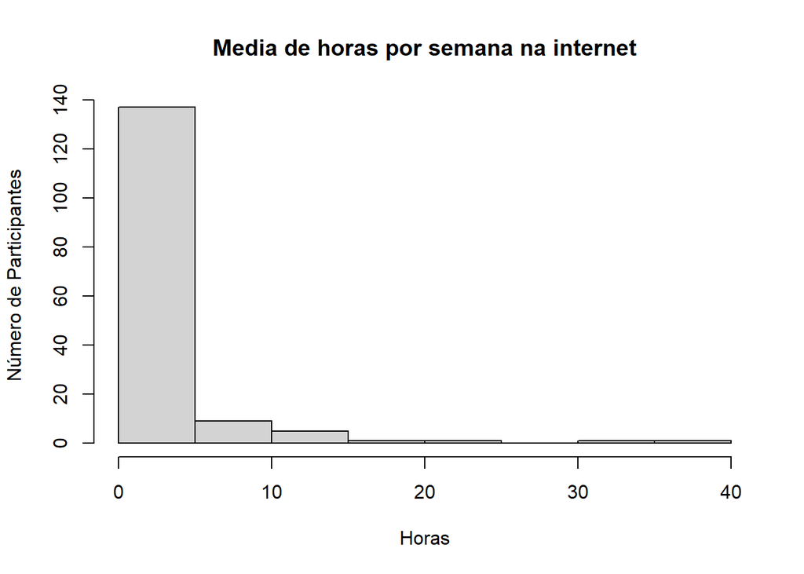

```r
hist(dati$Internet.use..mean.hours.per.week., main = "Media de horas por semana na internet",xlab = "Horas",ylab="Número de Participantes")
```

### Variável Depression.Before  
Grau de depressão antes do uso de internet.

```r
summary(dati$DepressionBefore)
```

```
##    Min. 1st Qu.  Median    Mean 3rd Qu.    Max.
##  0.0000  0.3333  0.6666  0.7337  1.0000  2.5332
```

```r
range (dati$DepressionBefore)
```

```
## [1] 0.000000 2.533203
```

```r
sd(dati$DepressionBefore)
```

```
## [1] 0.4962092
```

```r
var(dati$DepressionBefore)
```

```
## [1] 0.2462236
```

```r
fivenum((dati$DepressionBefore))
```

```
## [1] 0.000000 0.333313 0.666626 1.000000 2.533203
```

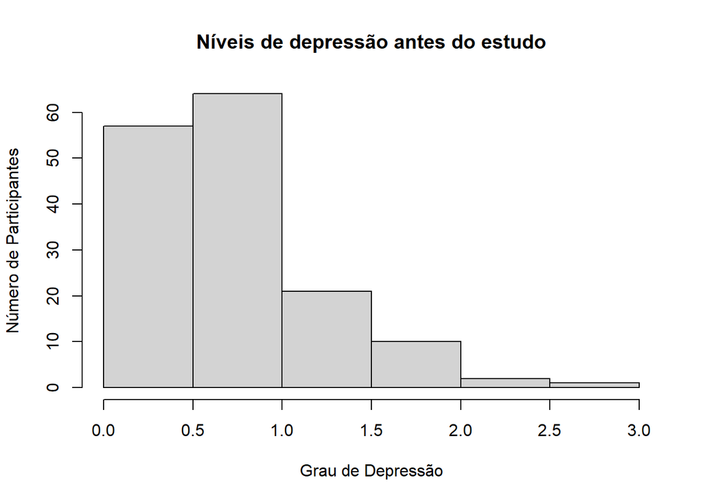

```r
hist(dati$DepressionBefore, main = "Níveis de depressão antes do estudo",xlab = "Grau de Depressão",ylab="Número de Participantes")
```

### Variável Depression.after

Grau de depressão após o uso de internet.

```r
summary(dati$DepressionAfter)
```

```
##    Min. 1st Qu.  Median    Mean 3rd Qu.    Max.
##  0.0000  0.2857  0.5000  0.6155  0.7856  3.0000
```

```r
range (dati$DepressionAfter)
```

```
## [1] 0 3
```

```r
sd(dati$DepressionAfter)
```

```
## [1] 0.4690264
```

```r
var(dati$DepressionAfter)
```

```
## [1] 0.2199857
```

```r
fivenum((dati$DepressionAfter))
```

```
## [1] 0.000000 0.285706 0.500000 0.785645 3.000000
```

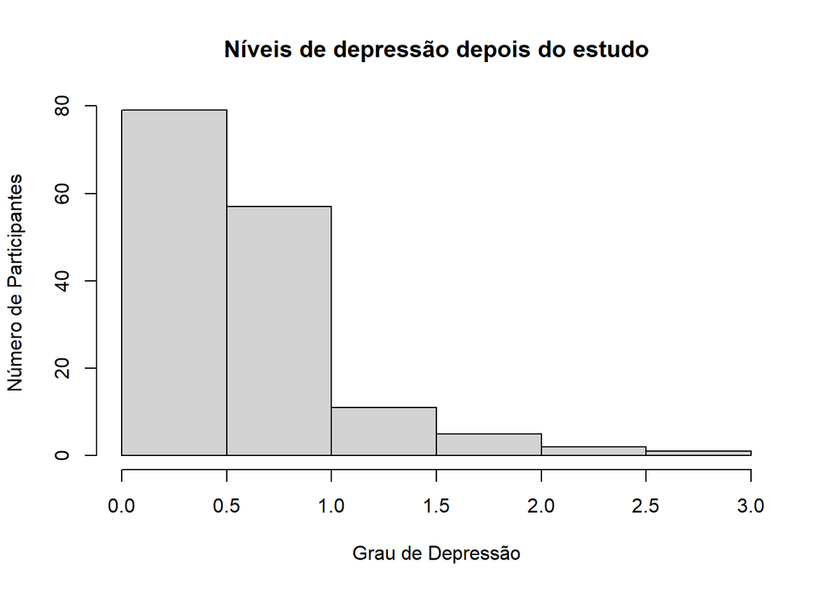

```r
hist(dati$DepressionAfter, main = "Níveis de depressão depois do estudo",xlab = "Grau de Depressão",ylab="Número de Participantes")
```

### Variável Gender

A variável Gender indica o género do participante, toma a designação “male” quando o participante é do género masculino e “female” quando é do género feminino.

```r
gender = table(dati$Gender)
names(gender) = c("Female","Male")
gender
```

```
## Female   Male
##     87     68
```

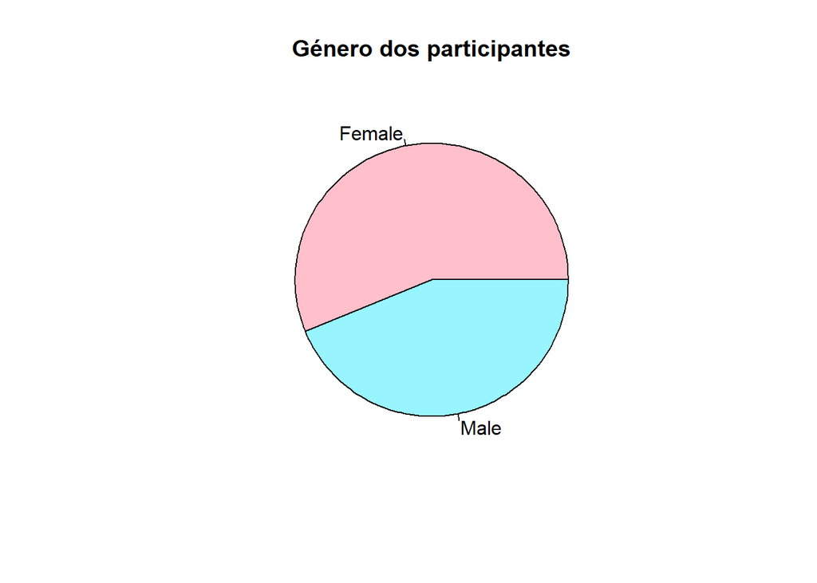

```r
pie(gender, labels = names(gender),col=c("pink","cadetblue1"), main = "Género dos participantes")
```

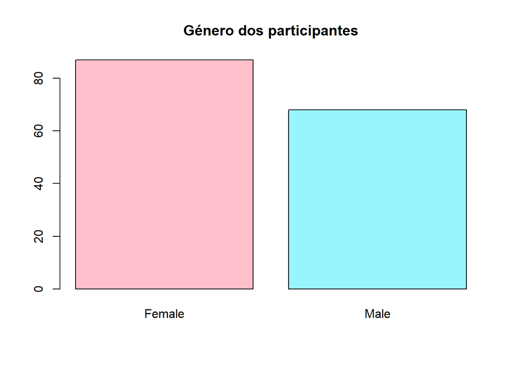

```r
barplot(gender, col = c("pink","cadetblue1"), main = "Género dos participantes" )
```

### Variável Race..white…1..minority…0

Variável que indica a etnia do participante. O seu valor é 1 quando o participante é branco e 0 quando o participante pertence a uma minoria.

```r
Etnia = table(dati$Race..white...1..minority...0.)
names(Etnia) = c("Minority","White")
Etnia
```

```
## Minority    White
##       34      121
```

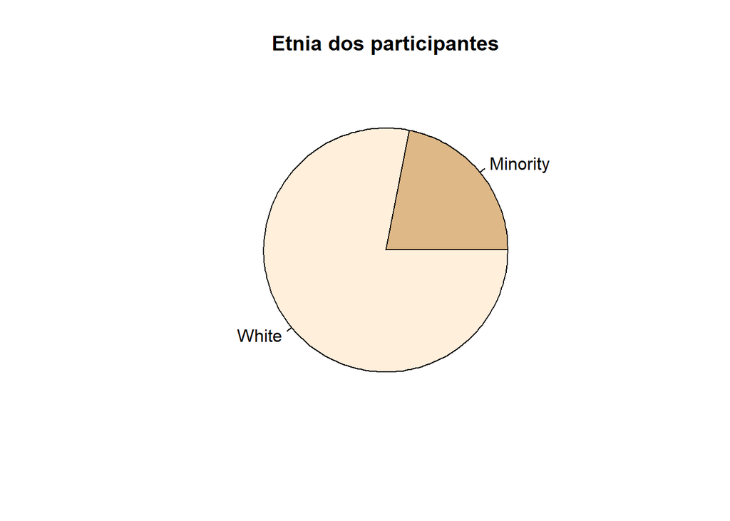

```r
pie(Etnia,col=c("burlywood","antiquewhite1"), main = "Etnia dos participantes")
```

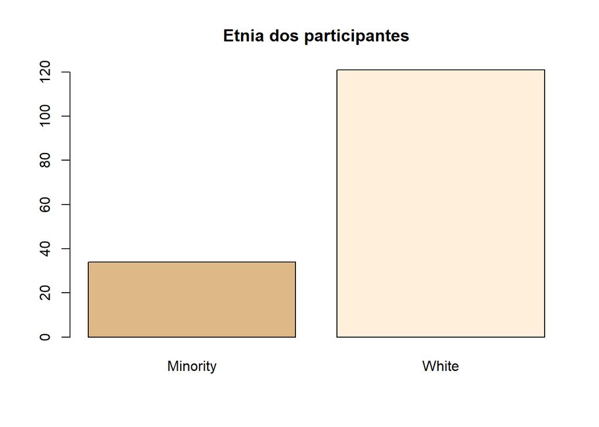

```r
barplot(Etnia, col = c("burlywood","antiquewhite1"), main = "Etnia dos participantes" )
```

### Variável Age

Variavel que indica o estagio da vida do participante, toma a designação de “Adult” quando o participante é adulto e “Teen” quando o participante é um adolescente.

```r
age = table(dati$Age)
names(age) = c("Teen","Adult")
age
```

```
##  Teen Adult
##   116    39
```

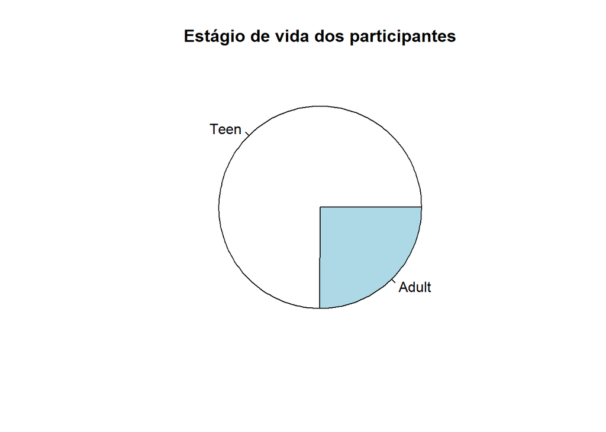

```r
pie(age, main = "Estágio de vida dos participantes")
```

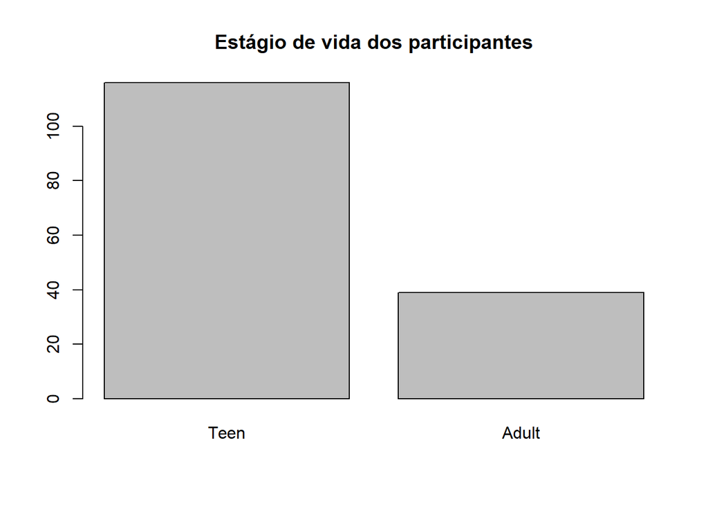

```r
barplot(age, main = "Estágio de vida dos participantes" )
```

### Variável Household.Income…000

Variavel do salário anual do agregado familiar em milhares.

```r
summary(dati$Household.income...000.)
```

```
##    Min. 1st Qu.  Median    Mean 3rd Qu.    Max.
##    5.00   36.46   52.50   54.52   85.00   85.00
```

```r
range (dati$Household.income...000.)
```

```
## [1]  5 85
```

```r
sd(dati$Household.income...000.)
```

```
## [1] 22.81019
```

```r
var(dati$Household.income...000.)
```

```
## [1] 520.3046
```

```r
fivenum((dati$Household.income...000.))
```

```
## [1]  5.00000 36.45834 52.50000 85.00000 85.00000
```

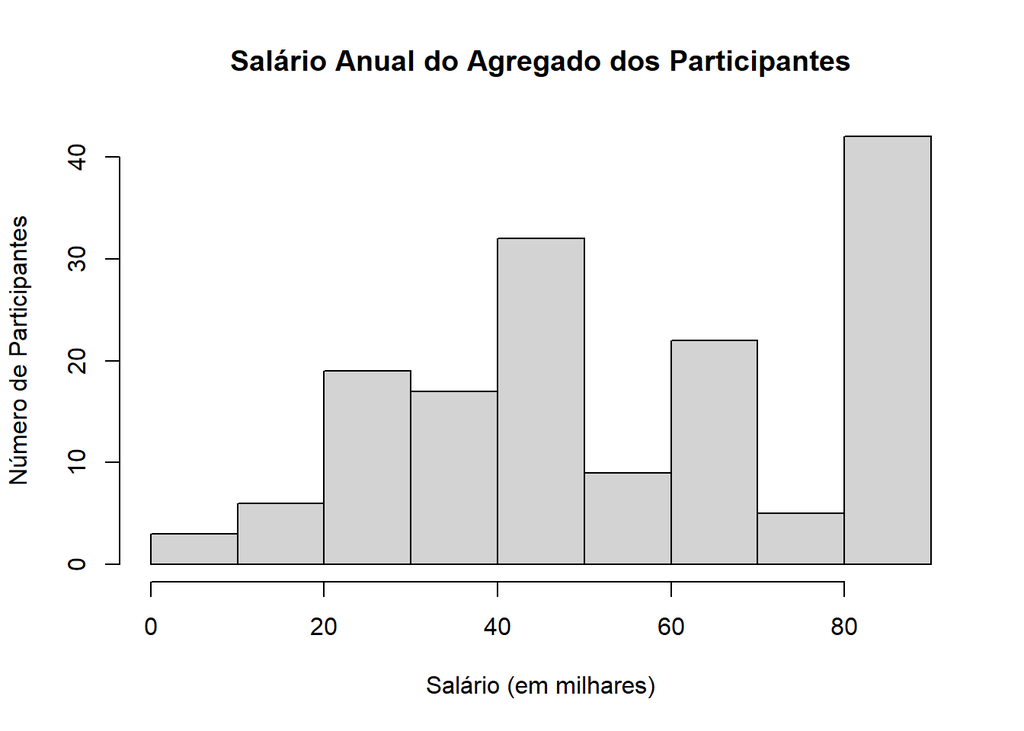

```r
hist(dati$Household.income...000., main = "Salário Anual do Agregado dos Participantes",xlab = "Salário (em milhares)",ylab="Número de Participantes")
```

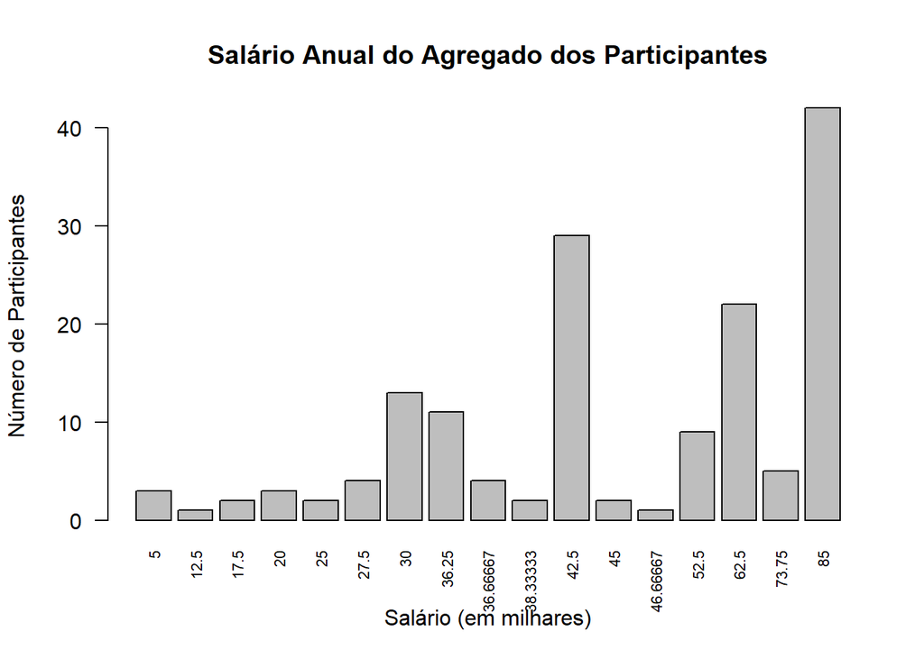

```r
sal= table(dati$Household.income...000.)
barplot(sal,main ="Salário Anual do Agregado dos Participantes", xlab="Salário (em milhares)", ,ylab="Número de Participantes", cex.names = 0.70,las= 2)
```

### Variável Household.size  
Variável que indica o tamanho do agregado familiar do participante.

```r
summary(dati$Household.size)
```

```
##    Min. 1st Qu.  Median    Mean 3rd Qu.    Max.
##   1.000   3.000   4.000   3.794   5.000   6.000
```

```r
range (dati$Household.size)
```

```
## [1] 1 6
```

```r
sd(dati$Household.size)
```

```
## [1] 1.204412
```

```r
var(dati$Household.size)
```

```
## [1] 1.450607
```

```r
fivenum((dati$Household.size))
```

```
## [1] 1 3 4 5 6
```

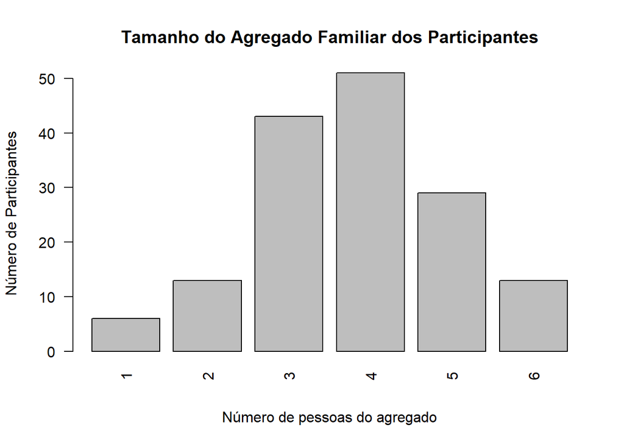

```r
agr= table(dati$Household.size)
barplot(agr,main ="Tamanho do Agregado Familiar dos Participantes", xlab="Número de pessoas do agregado", ,ylab="Número de Participantes", cex.names = 1,las= 2)
```

# Correlações

## Antes do estudo

```r
db = dati$DepressionBefore
```

### Depressão por género

H0: O grau de depressão não é correlacionado com género do participante.  
H1: O grau de depressão é correlacionado com género do participante.

```r
model1b = lm (db~dati$Gender)
model1b
```

```
##
## Call:
## lm(formula = db ~ dati$Gender)
##
## Coefficients:
##     (Intercept)  dati$Gendermale
##         0.76492         -0.07113
```

```r
summary(model1b)
```

```
##
## Call:
## lm(formula = db ~ dati$Gender)
##
## Residuals:
##      Min       1Q   Median       3Q      Max
## -0.76492 -0.42713 -0.05069  0.23726  1.76828
##
## Coefficients:
##                 Estimate Std. Error t value Pr(>|t|)
## (Intercept)      0.76492    0.05324  14.368   <2e-16 ***
## dati$Gendermale -0.07113    0.08038  -0.885    0.378
## ---
## Signif. codes:  0 '***' 0.001 '**' 0.01 '*' 0.05 '.' 0.1 ' ' 1
##
## Residual standard error: 0.4966 on 153 degrees of freedom
## Multiple R-squared:  0.005092,   Adjusted R-squared:  -0.00141
## F-statistic: 0.7831 on 1 and 153 DF,  p-value: 0.3776
```

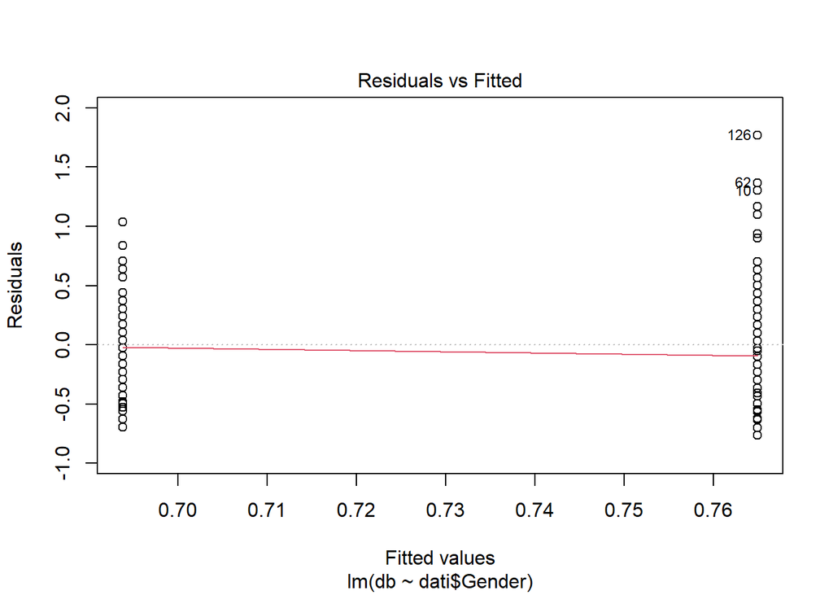

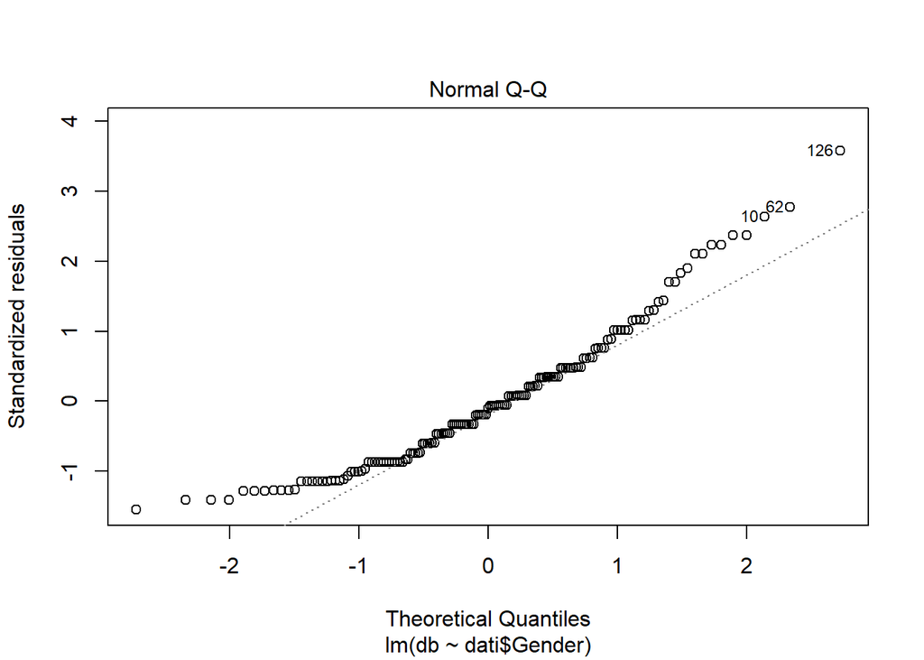

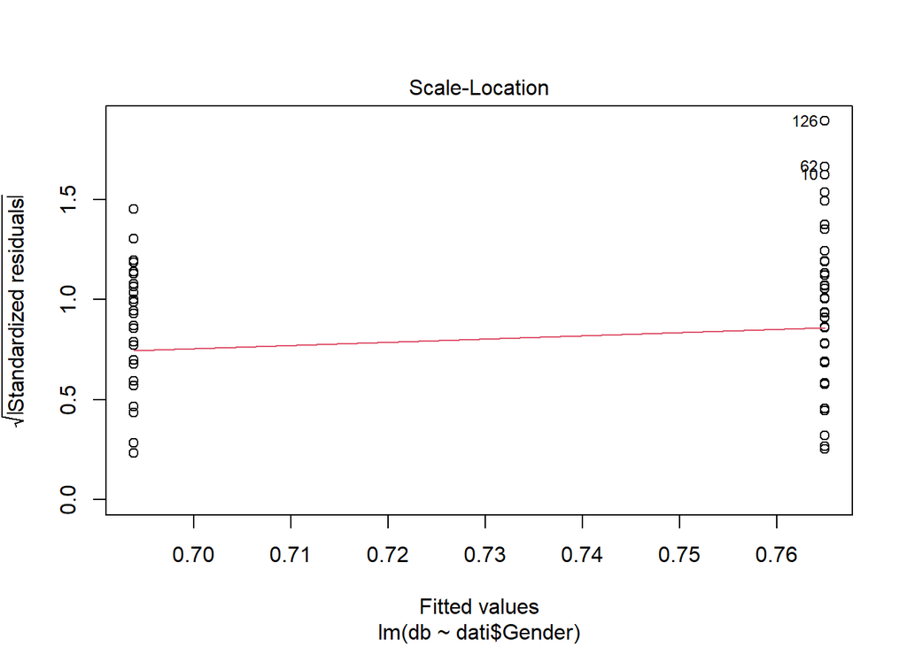

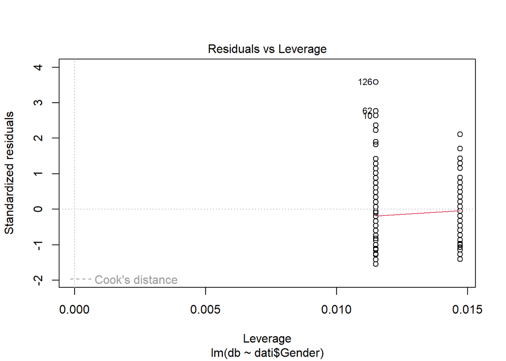

```r
plot(model1b)
```

Como o p-value é maior do que 0.05, não podemos rejeitar a H0, pelo que existem evidências de que antes do uso de internet o grau de depressão pode não ter qualquer correlação com o género do participante.

### Depressão por etnia.

H0: O grau de depressão não é correlacionado com a etnia do participante.  
H1: O grau de depressão é correlacionado com a etnia do participante.

```r
model2b =lm(db~dati$Race..white...1..minority...0.)
model2b
```

```
##
## Call:
## lm(formula = db ~ dati$Race..white...1..minority...0.)
##
## Coefficients:
##                         (Intercept)  dati$Race..white...1..minority...0.
##                             0.69940                              0.04396
```

```r
summary(model2b)
```

```
##
## Call:
## lm(formula = db ~ dati$Race..white...1..minority...0.)
##
## Residuals:
##      Min       1Q   Median       3Q      Max
## -0.74336 -0.38807 -0.07673  0.25664  1.78985
##
## Coefficients:
##                                     Estimate Std. Error t value Pr(>|t|)
## (Intercept)                          0.69940    0.08532   8.197  9.2e-14 ***
## dati$Race..white...1..minority...0.  0.04396    0.09656   0.455     0.65
## ---
## Signif. codes:  0 '***' 0.001 '**' 0.01 '*' 0.05 '.' 0.1 ' ' 1
##
## Residual standard error: 0.4975 on 153 degrees of freedom
## Multiple R-squared:  0.001352,   Adjusted R-squared:  -0.005175
## F-statistic: 0.2072 on 1 and 153 DF,  p-value: 0.6496
```

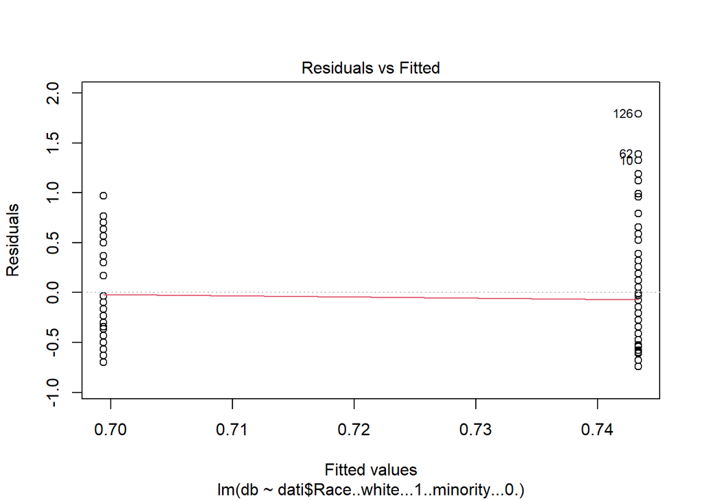

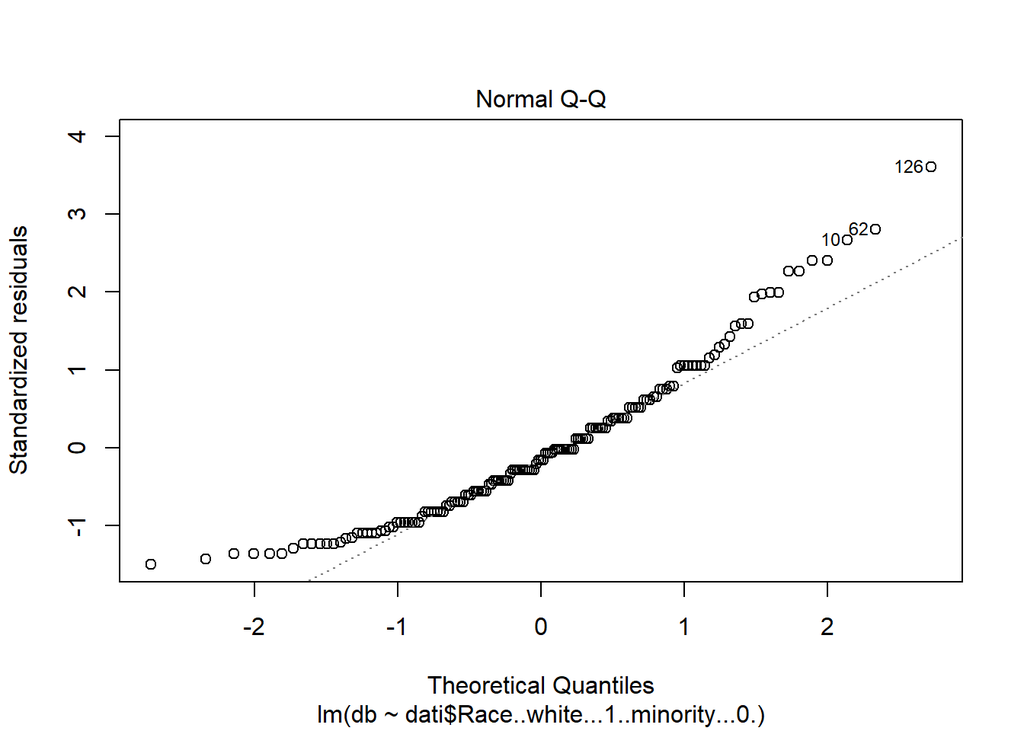

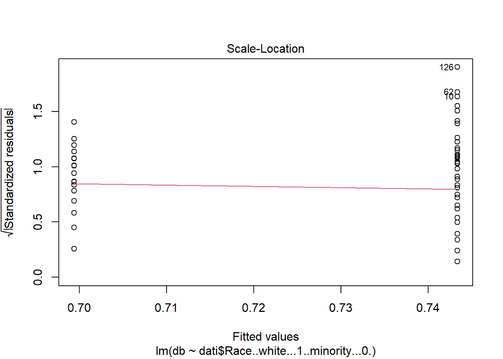

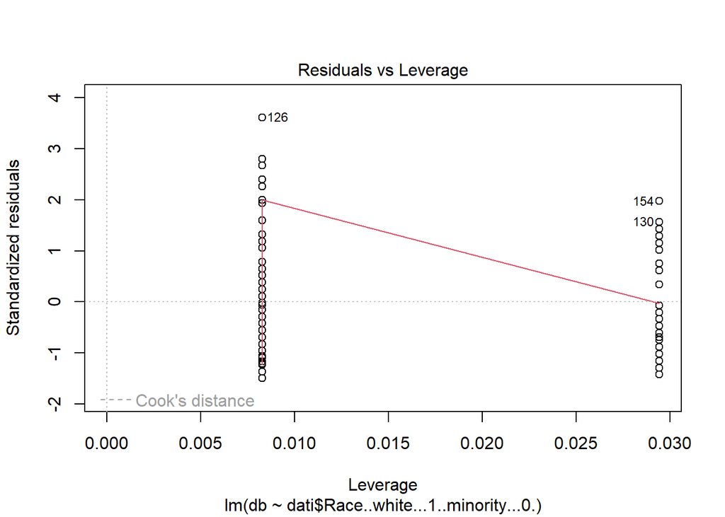

```r
plot(model2b)
```

Como o p-value é maior do que 0.05, não podemos rejeitar a H0, pelo que existem evidência de antes do uso de internet o grau de depressão pode não ter qualquer correlação com a etnia do participante.

### Depressão por idade.

H0: O grau de depressão não é correlacionado com a idade do participante.  
H1: O grau de depressão é correlacionado com a idade do participante.

```r
model3b = lm(db~dati$Age)
model3b
```

```
##
## Call:
## lm(formula = db ~ dati$Age)
##
## Coefficients:
##  (Intercept)  dati$AgeTeen
##       0.6356        0.3900
```

```r
summary(model3b)
```

```
##
## Call:
## lm(formula = db ~ dati$Age)
##
## Residuals:
##      Min       1Q   Median       3Q      Max
## -0.95890 -0.30228 -0.09234  0.23601  1.50764
##
## Coefficients:
##              Estimate Std. Error t value Pr(>|t|)
## (Intercept)   0.63559    0.04343  14.634  < 2e-16 ***
## dati$AgeTeen  0.38997    0.08659   4.504 1.32e-05 ***
## ---
## Signif. codes:  0 '***' 0.001 '**' 0.01 '*' 0.05 '.' 0.1 ' ' 1
##
## Residual standard error: 0.4678 on 153 degrees of freedom
## Multiple R-squared:  0.1171, Adjusted R-squared:  0.1113
## F-statistic: 20.28 on 1 and 153 DF,  p-value: 1.316e-05
```

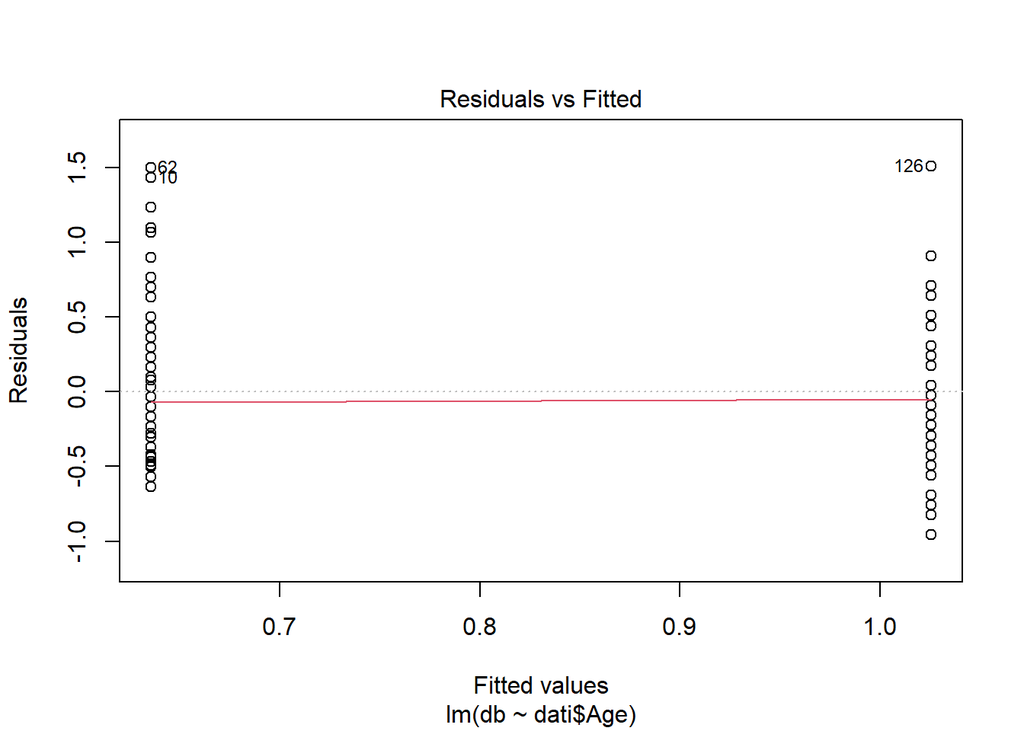

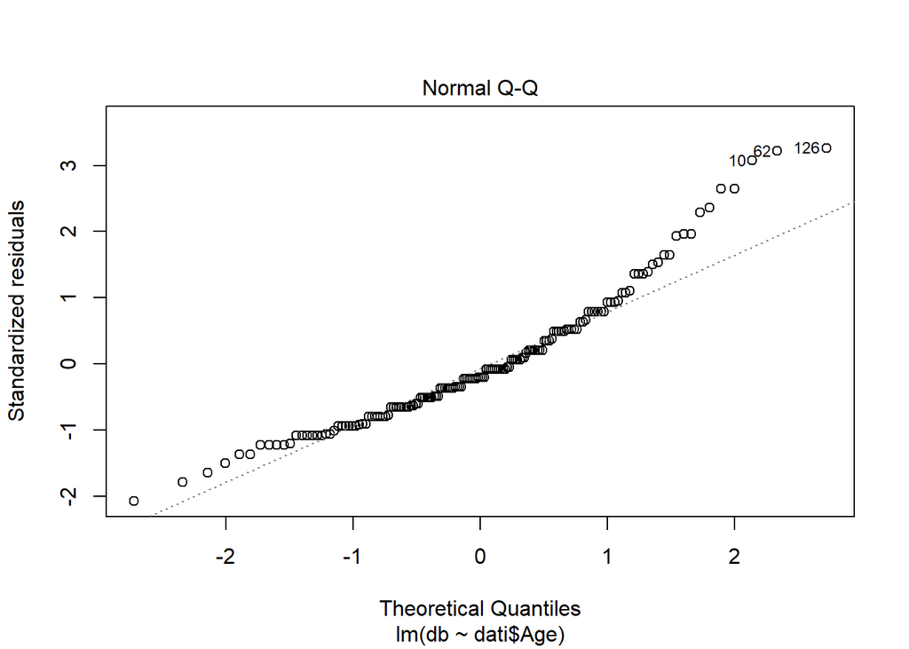

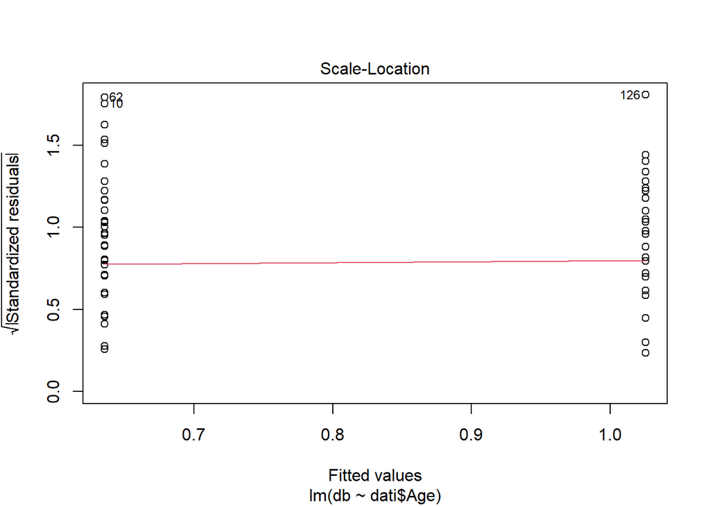

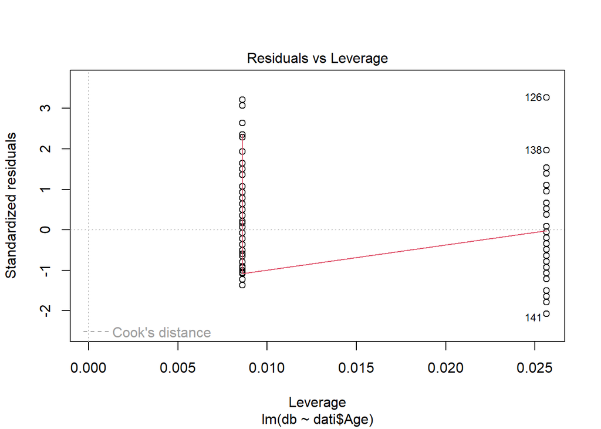

```r
plot(model3b)
```

Como o p-value é menor do que 0.05,podemos rejeitar a H0, o que nos sugere a existência de evidência que nos pode indicar uma correlação do grau de depressão com o estagio da vida do participante antes do uso de internet.

### Depressão por salário.

H0: O grau de depressão não é correlacionado com o salário do agregado familiar do participante.  
H1: O grau de depressão é correlacionado com o salário do agregado familiar do participante.

```r
model4b=lm(db~dati$Household.income...000.)
model4b
```

```
##
## Call:
## lm(formula = db ~ dati$Household.income...000.)
##
## Coefficients:
##                  (Intercept)  dati$Household.income...000.
##                     0.650214                      0.001532
```

```r
summary(model4b)
```

```
##
## Call:
## lm(formula = db ~ dati$Household.income...000.)
##
## Residuals:
##      Min       1Q   Median       3Q      Max
## -0.74594 -0.38122 -0.07932  0.27703  1.81789
##
## Coefficients:
##                              Estimate Std. Error t value Pr(>|t|)
## (Intercept)                  0.650214   0.103624   6.275 3.43e-09 ***
## dati$Household.income...000. 0.001532   0.001754   0.873    0.384
## ---
## Signif. codes:  0 '***' 0.001 '**' 0.01 '*' 0.05 '.' 0.1 ' ' 1
##
## Residual standard error: 0.4966 on 153 degrees of freedom
## Multiple R-squared:  0.004957,   Adjusted R-squared:  -0.001546
## F-statistic: 0.7623 on 1 and 153 DF,  p-value: 0.384
```

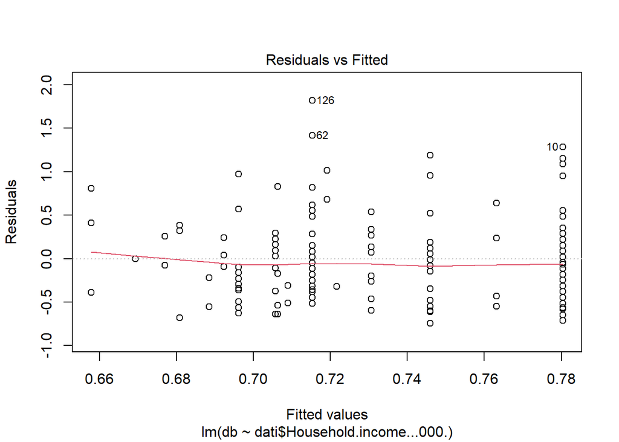

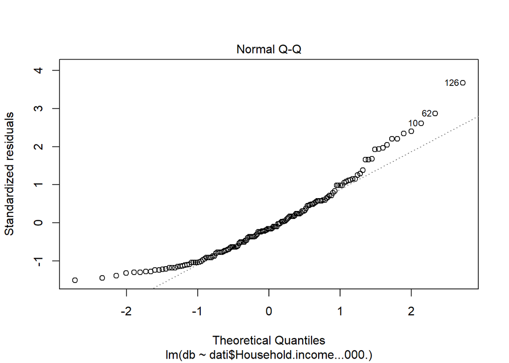

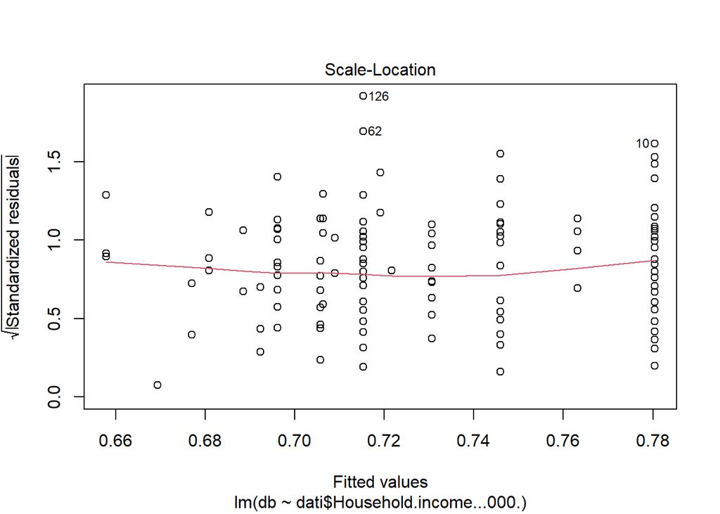

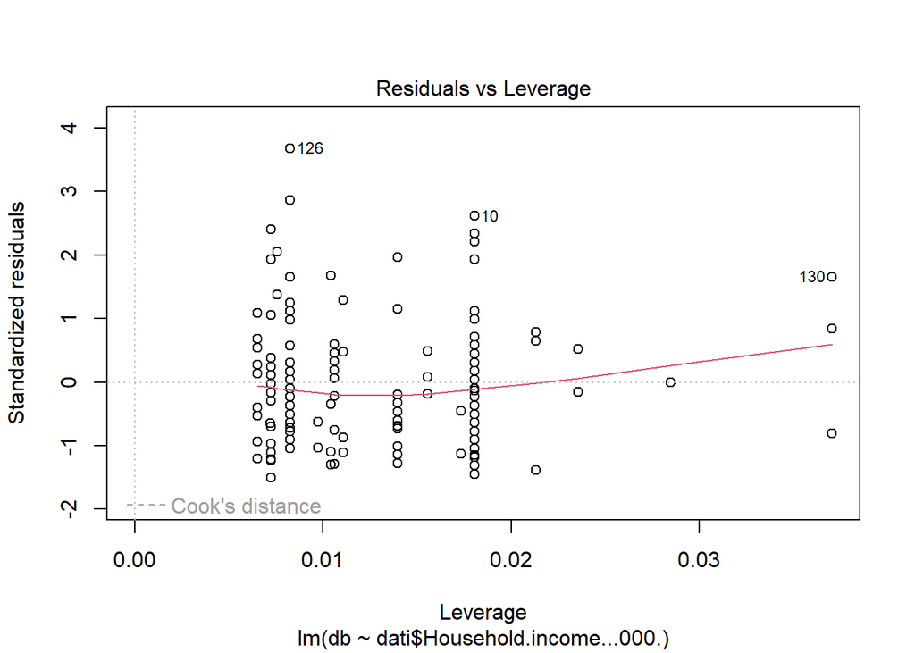

```r
plot(model4b)
```

Como o p-value é maior do que 0.05, não podemos rejeitar a H0, pelo que existem evidencias que antes do uso de internet o grau de depressão não está correlacionado com o salário do agregado familiar do participante.

### Depression por tamanho do agregado familiar

```r
model5b=lm(db~dati$Household.size)
model5b
```

```
##
## Call:
## lm(formula = db ~ dati$Household.size)
##
## Coefficients:
##         (Intercept)  dati$Household.size
##             0.49802              0.06213
```

```r
summary(model5b)
```

```
##
## Call:
## lm(formula = db ~ dati$Household.size)
##
## Residuals:
##     Min      1Q  Median      3Q     Max
## -0.6844 -0.4087 -0.0754  0.2489  1.6624
##
## Coefficients:
##                     Estimate Std. Error t value Pr(>|t|)
## (Intercept)          0.49802    0.13101   3.801 0.000207 ***
## dati$Household.size  0.06213    0.03293   1.887 0.061060 .
## ---
## Signif. codes:  0 '***' 0.001 '**' 0.01 '*' 0.05 '.' 0.1 ' ' 1
##
## Residual standard error: 0.4921 on 153 degrees of freedom
## Multiple R-squared:  0.02274,    Adjusted R-squared:  0.01636
## F-statistic: 3.561 on 1 and 153 DF,  p-value: 0.06106
```

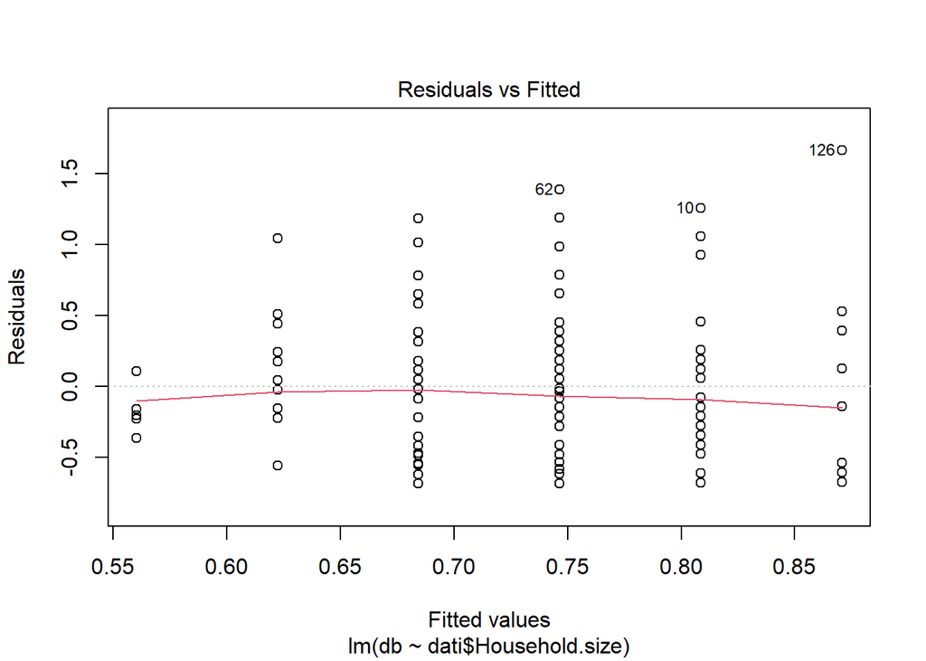

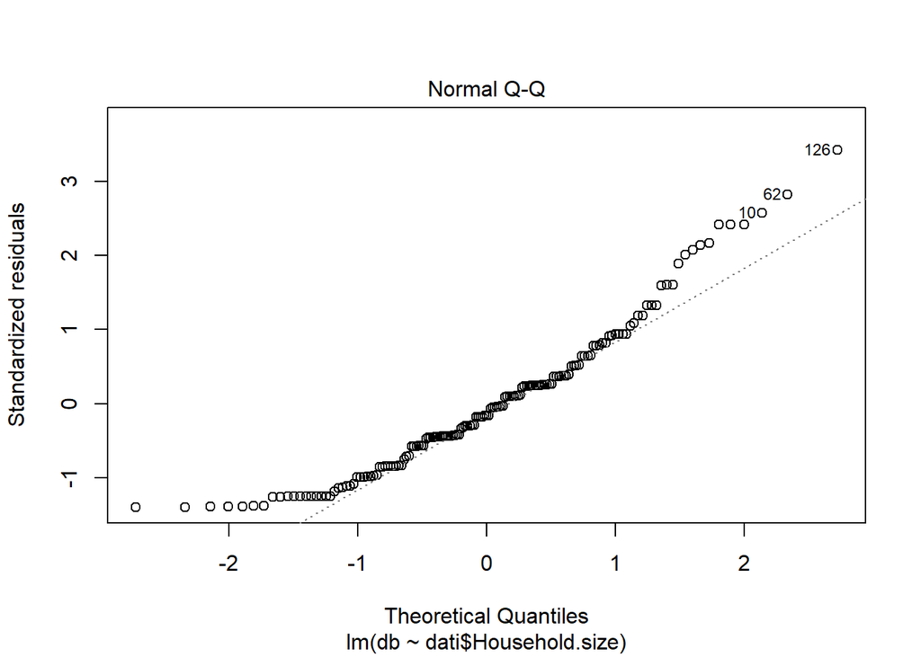

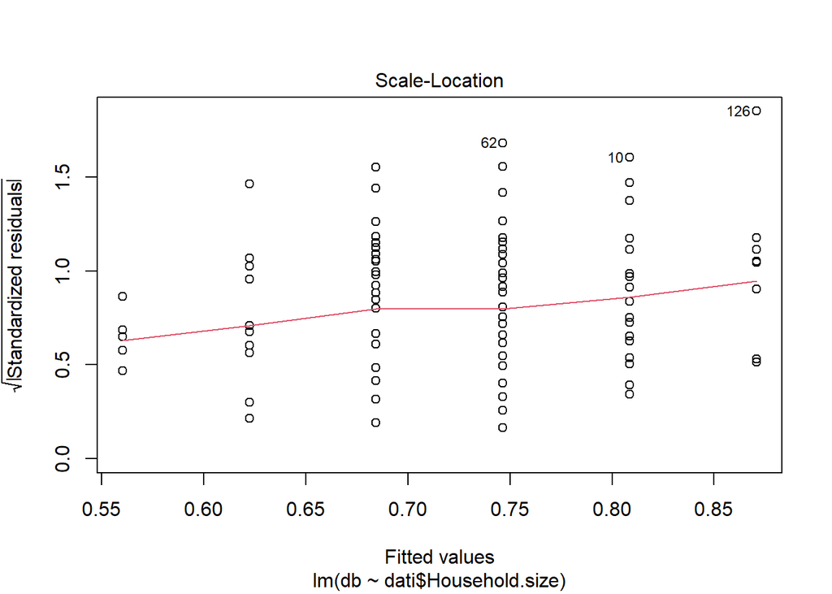

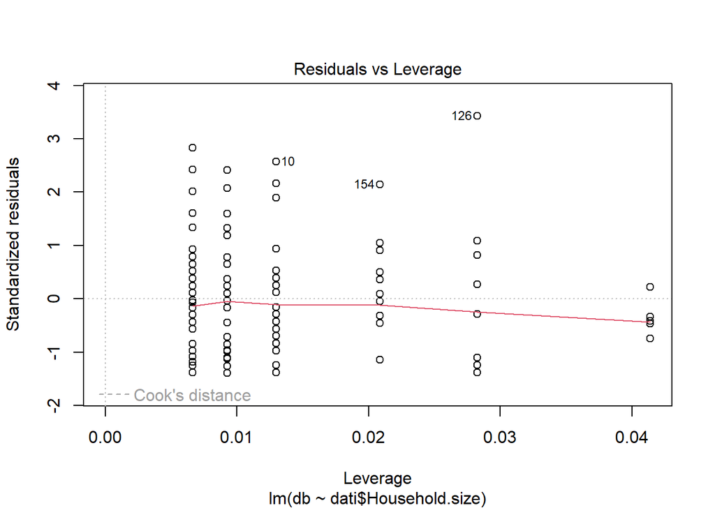

```r
plot(model5b)
```

```r
da=dati$DepressionAfter
```